# Communicating Data Finding : Ford GoBike System Data

## by Dain Russell

## Investigation Overview

In this investigation, I wanted to look at different features of the bikeshare dataset that influence trip duration.

## Dataset Overview

The data consisted of trip start and end times and other variables.

- There were 4646 bikes.
- There are 183412 fordgobike trips in the cleaned dataset with 16 specifications or columns.

## Connect to the dataset

|  | duration_sec | start_time | end_time | start_station_id | start_station_name | start_station_latitude | start_station_longitude | end_station_id | end_station_name | end_station_latitude | end_station_longitude | bike_id | user_type | member_birth_year | member_gender | bike_share_for_all_trip |
| --- | --- | --- | --- | --- | --- | --- | --- | --- | --- | --- | --- | --- | --- | --- | --- | --- |
| 0 | 52185 | 2019-02-28 17:32:10.1450 | 2019-03-01 08:01:55.9750 | 21.0 | Montgomery St BART Station (Market St at 2nd St) | 37.789625 | -122.400811 | 13.0 | Commercial St at Montgomery St | 37.794231 | -122.402923 | 4902 | Customer | 1984.0 | Male | No |
| 1 | 42521 | 2019-02-28 18:53:21.7890 | 2019-03-01 06:42:03.0560 | 23.0 | The Embarcadero at Steuart St | 37.791464 | -122.391034 | 81.0 | Berry St at 4th St | 37.775880 | -122.393170 | 2535 | Customer | NaN | NaN | No |
| 2 | 61854 | 2019-02-28 12:13:13.2180 | 2019-03-01 05:24:08.1460 | 86.0 | Market St at Dolores St | 37.769305 | -122.426826 | 3.0 | Powell St BART Station (Market St at 4th St) | 37.786375 | -122.404904 | 5905 | Customer | 1972.0 | Male | No |
| 3 | 36490 | 2019-02-28 17:54:26.0100 | 2019-03-01 04:02:36.8420 | 375.0 | Grove St at Masonic Ave | 37.774836 | -122.446546 | 70.0 | Central Ave at Fell St | 37.773311 | -122.444293 | 6638 | Subscriber | 1989.0 | Other | No |
| 4 | 1585 | 2019-02-28 23:54:18.5490 | 2019-03-01 00:20:44.0740 | 7.0 | Frank H Ogawa Plaza | 37.804562 | -122.271738 | 222.0 | 10th Ave at E 15th St | 37.792714 | -122.248780 | 4898 | Subscriber | 1974.0 | Male | Yes |

## Distribution of Bike Trip Duration

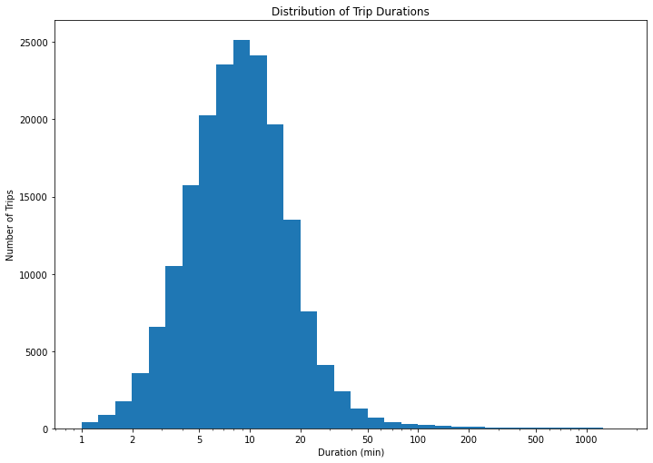

### Observations

With this distribution I really wanted to see how the trip was distributed when looking at just the length of a ride. According to baywheels.com, trips longer than 45 minutes will incur an extra 3 dollars per each additional 45-minutes for those with an annual pass. A single ride cost 3 dollars and only last 30 minutes This fact probably factors into how long a user will ride and why the data shows most trips are below 45 minutes.

## Distribution of Users

**User Type Key** 1.Customer = 24-hour pass or 3-day pass user 2.Subscriber = Annual Member

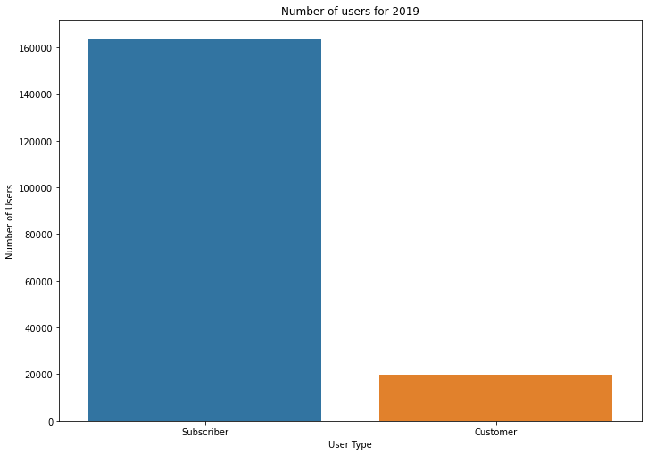

### Observations

- Users included Customer that represents those with a 24-hour pass or 3-day pass, and subscribers those with anual membership.
- The bar chart shows over 160,000 subscribing users and 20,000 customers.
- Most users are actually subscribers with annual memberships.

Due to the fact that there are so many more people subscribing that using a single day or 3 day pass I think can be attributed to the cost savings. I think there are so many users that are riding bikes daily, tht it makes more cost sense to sign up for an annual membership.

## Distribution of Gender

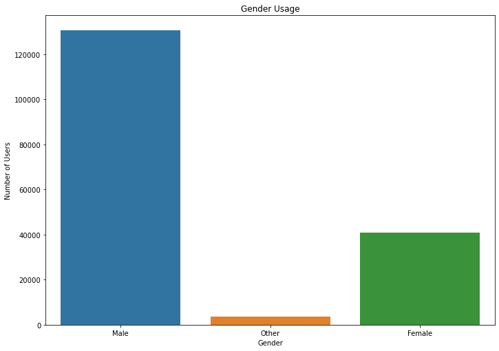

### Observations

- Males use the bike service overwhelmingly more than females and other genders.
- Over 120,000 males used the service in 2019.

The intent was to see how each gender type is spread out and how much of each group is using the bike share service.This distribution reveals that males represents most of the riders. Could this be because males are more into this type of fitness activity. We should have a clearr picture if we factor in more variables like age to see what group of males this number represents.

## Trip Duration and Age

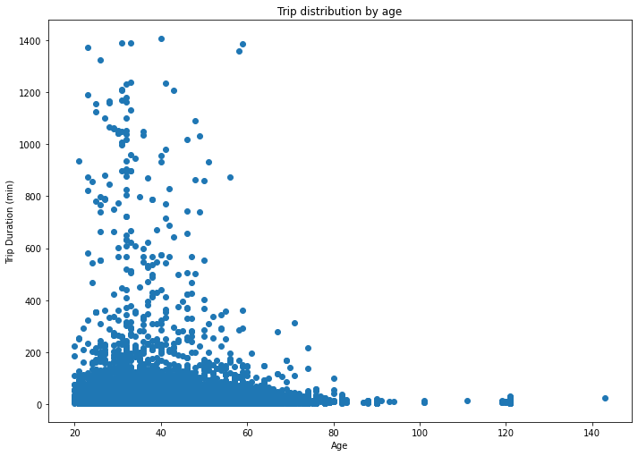

### Observation

So with this plot I wanted to look at how trip duration is affected by the age of the user. You can observe that there is a negative correlation where the age decreases as the trip duration increases. The concentration of rides are for persons between ages 25 and 45 showing the inverse relationship between age and the trip duration. It is not surprising that biking trip duration would decrease as you increase in age. Fitness would be less common or intense mong older groups so the bike trip would decrease among a older group.

## Trip Duration and User Type

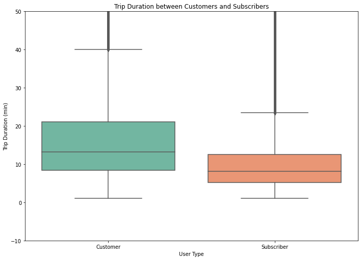

## Trip Duration vs Weekday and Gender Type

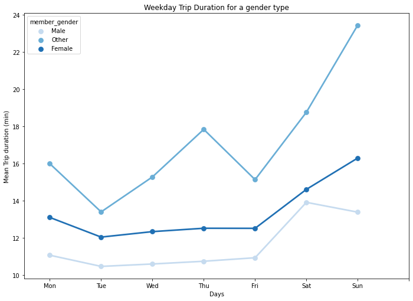

### Observation

All the gender groups peaked on Fridays to Sunday and increased the length of their bike trips. That makes sense as those riders probably have more time to dedicate to riding. They are probably riding at a different time of day. I notice that although males increase their trip on Fridays to Saturday they are recording the shortest trips of all gender type.